# An Implementation of K-means++, Part 1

jacquesattack

2018-10-17

# Introduction

Previously I wrote about K-means clustering using Lloyd’s Algorithm. That algorithm can be split into two parts:

1. Choosing initial centers
2. Iterating until final centers are chosen

I mostly ignored step 1 by choosing centers randomly from the available data. However, there are other ways to choose centers, and choosing centers randomly can lead to various problems. For example, the number of steps to convergence could be much larger if the initial centers are very closer together than if the initial centers were closer to their final positions. To overcome these, we might choose centers in a special way. K-means++ is one of these special ways. In this post I will present a K-means++ algorithm and show some results.

The Wikipedia article with this and more information can be found [here](https://en.wikipedia.org/wiki/K-means%2B%2B).

# Steps To Convergence

Before I show my K-means++ algorithm, I will first make some changes to my K-means algorithm. First I would like to be able to specify the initial centers myself. Second, I would like to save the centroids at each step so that I can compare random initial center assignment to K-means++ by how many steps are needed to reach convergence. Note that I also fixed a bug which sometimes caused `new_centroids` to be in the wrong order. This was discovered when I printed out the results at the bottom.

```r
library(tidyverse)
library(magrittr)

dist = function(v1,v2) {
  sqrt(sum((v1-v2)^2))
}

solve_k_means = function(data,k,centroids){
  count = 1
  all_centers = list()
  all_centers[[count]] = centroids

  repeat {
    count = count + 1

    # assign each data point to its closest centroid
    groups = sapply(1:nrow(data),function(i){
      which.min(apply(centroids,1,function(row){
        dist(row,data[i,])
      }))
    })

    # calculate new centroids
    new_centroids = t(sapply(1:k,function(g){
      which_data = which(groups == g)
      sapply(1:ncol(data),function(j){
        mean(data[which_data,j])
      })
    }))

    all_centers[[count]] = new_centroids %>%
      as_tibble %>% set_colnames(c("x","y"))

    # if centroids didn't change, break
    if(all(sapply(1:ncol(data),function(i){
      all(centroids[,i] == new_centroids[,i])
    }))){
      break
    }

    centroids = new_centroids
  }
  all_centers
}
```

Here’s an example showing how to use the new output:

```r
k = 2
data = faithful %>% rename(x=eruptions,y=waiting)
initial_centers = data[sample(1:nrow(data),k),] %>% as_tibble
output = solve_k_means(data,2,initial_centers)

print(output)
```

```
## [[1]]
## # A tibble: 2 x 2
##       x     y
## * <dbl> <dbl>
## 1  4.82  77.0
## 2  4.80  75.0
##
## [[2]]
## # A tibble: 2 x 2
##       x     y
##   <dbl> <dbl>
## 1  4.36  82.6
## 2  2.69  60.2
##
## [[3]]
## # A tibble: 2 x 2
##       x     y
##   <dbl> <dbl>
## 1  4.34  81.0
## 2  2.26  56.4
##
## [[4]]
## # A tibble: 2 x 2
##       x     y
##   <dbl> <dbl>
## 1  4.30  80.4
## 2  2.11  54.9
##
## [[5]]
## # A tibble: 2 x 2
##       x     y
##   <dbl> <dbl>
## 1  4.30  80.3
## 2  2.09  54.8
##
## [[6]]
## # A tibble: 2 x 2
##       x     y
##   <dbl> <dbl>
## 1  4.30  80.3
## 2  2.09  54.8
```

To make it more exciting, let’s plot the path of each center as it approaches convergence:

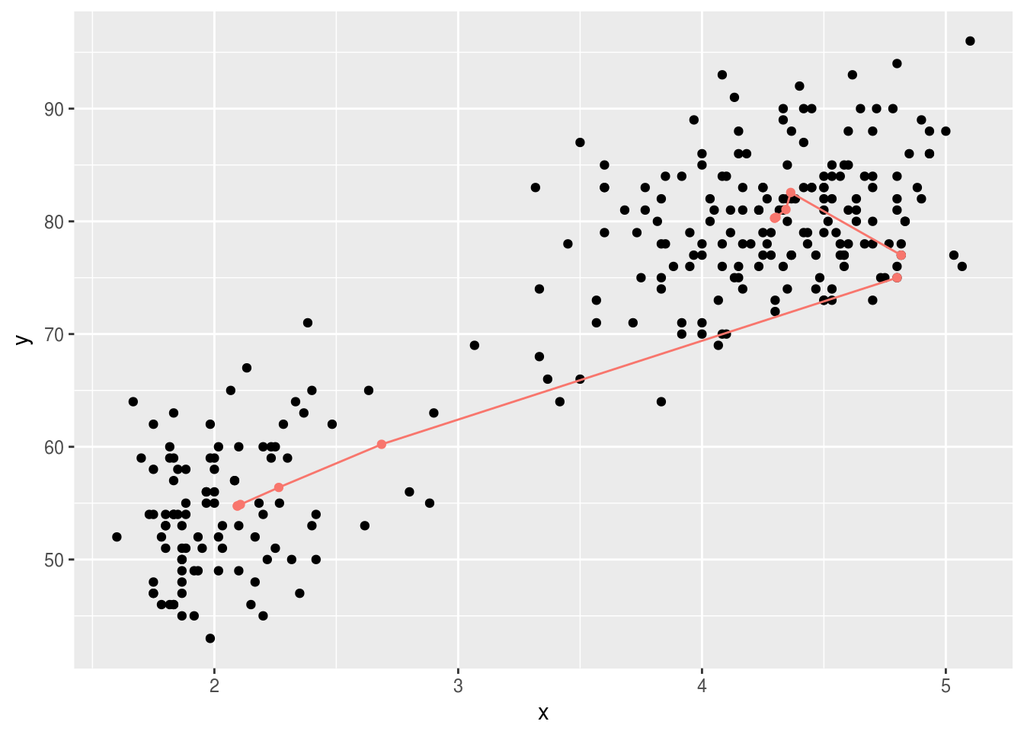

```r
g = ggplot(data,aes(x=x,y=y)) + geom_point()
for(i in 1:length(output)){
  g = g + geom_point(data=output[[i]], aes(x=x,y=y,colour="red"))
  if(i < length(output)){
    combined = bind_cols(output[[i]],output[[i+1]]) %>%
      set_colnames(c("x","y","xend","yend"))
    g = g + geom_segment(data = combined,
               aes(x = x, y = y, xend = xend,
                   yend = yend, colour = "red"))
  }
}
g = g + theme(legend.position="none")
g
```